# 8. Intractability II

8. Intractability II

WU Xiaokun 吴晓堃

xkun.wu [at] gmail

2021/11/19

## Recap: Poly-time reductions

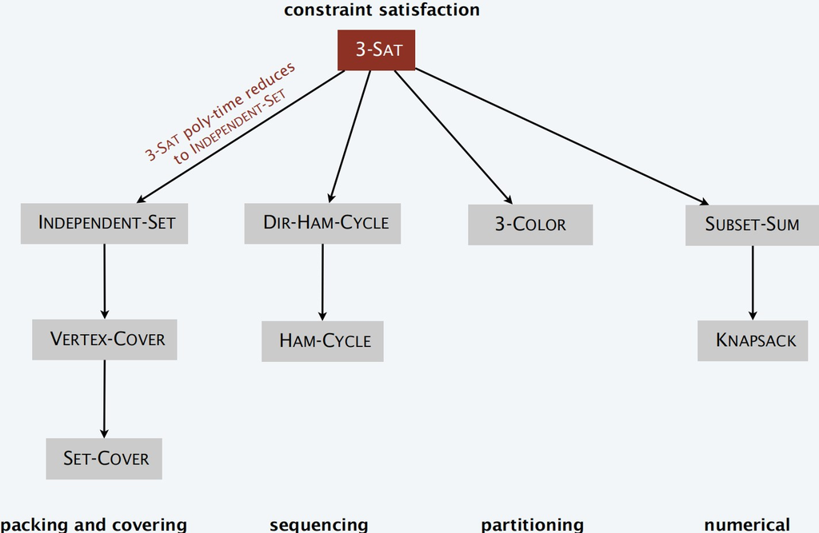

# $\mathcal{P}$ vs. $\mathcal{NP}$

## $\mathcal{P}$

**Decision problem**.

- Problem $X$ is a set of strings.
- Instance $s$ is one string.
- Algorithm $A$ solves problem $X$:

$$A(s) = \left\{ \begin{array}{ll}
yes & \text{if}\ s \in X \\
no & \text{if}\ s \notin X \\
\end{array}\right.$$

**Def**. Algorithm $A$ runs in **polynomial time** if for every string $s$, $A(s)$ terminates in $\le p(|s|)$ “steps,” where $p(\cdot)$ is some polynomial function.

**Def**. **$\mathcal{P}$** = set of decision problems for which there exists a poly-time algorithm.

**Ex**. **PRIMES**

- problem: $\{ 2, 3, 5, 7, 11, 13, 17, 19, 23, 29, 31, \ldots \}$
- instance $s$: $592335744548702854681$
- algorithm: Agrawal-Kayal-Saxena (2002)

## Some problems in $\mathcal{P}$

**$\mathcal{P}$**. Decision problems for which there exists a poly-time algorithm.

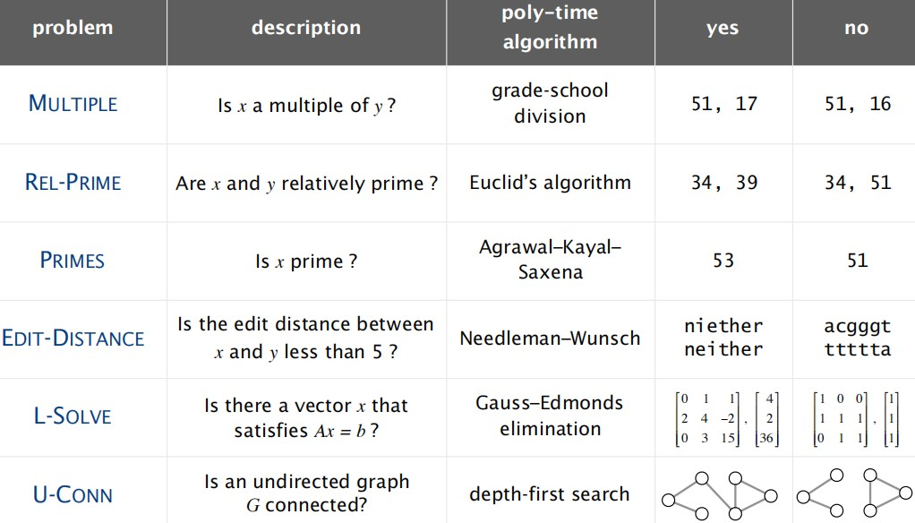

## $\mathcal{NP}$

**Def**. Algorithm $C(s, t)$ is a **certifier** for problem $X$ if for every string $s: s \in X$ iff there exists a string $t$ such that $C(s, t) = yes$.

**Def**. **$\mathcal{NP}$** = set of decision problems for which there exists a poly-time certifier.

- $C(s, t)$ is a poly-time algorithm.
- Certificate $t$ is of polynomial size: $|t| \le p(|s|)$ for some polynomial $p(\cdot)$.

**Ex**. **COMPOSITES**

- problem: $\{ 4, 6, 8, 9, 10, 12, 14, 15, 16, 18, 20, \ldots \}$
- instance $s$: $437669$
- certificate $t$: $541$ ($437,669 = 541 \times 809$)
- certifier $C(s, t)$: grade-school division

## Certifiers and certificates: satisfiability

**SAT**. Given a CNF formula $\Phi$, does it have a satisfying truth assignment?

**3-SAT**. SAT where each clause contains exactly 3 literals.

**Certificate**. An assignment of truth values to the Boolean variables.

**Certifier**. Check that each clause in $\Phi$ has at least one true literal.

**Ex**.

- instance $s$: $\Phi = ( x_1 \vee x_2 \vee x_3) \wedge ( x_1 \vee x_2 \vee x_3) \wedge ( x_1 \vee x_2 \vee x_4 )$
- certificate $t$: $x_1 = true, x_2 = true, x_3 = false, x_4 = false$

**Conclusions**. SAT $\in \mathcal{NP}$, 3-SAT $\in \mathcal{NP}$.

## Certifiers and certificates: Hamilton path

**HAMILTON-PATH**. Given an undirected graph $G = (V, E)$, does there exist a simple path $P$ that visits every node?

**Certificate**. A permutation $\pi$ of the $n$ nodes.

**Certifier**. Check that $\pi$ contains each node in $V$ exactly once, and that $G$ contains an edge between each pair of adjacent nodes.

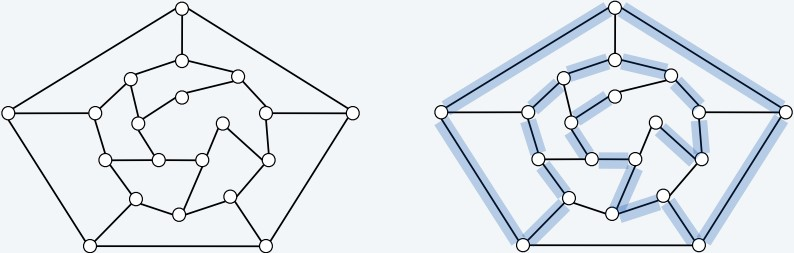

**Conclusion**. HAMILTON-PATH $\in \mathcal{NP}$.

## Some problems in $\mathcal{NP}$

**$\mathcal{NP}$**. Decision problems for which there exists a poly-time certifier.

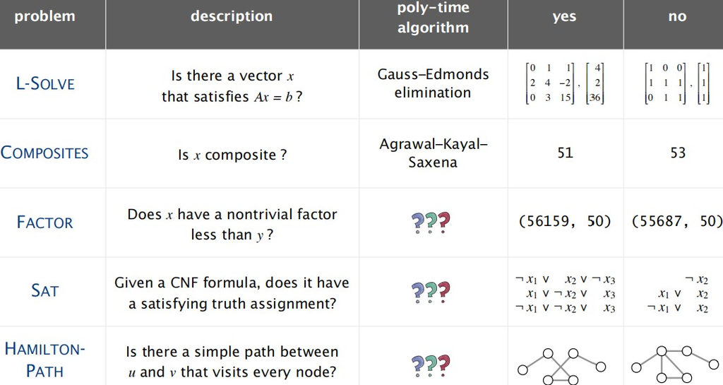

## $\mathcal{P}$, $\mathcal{NP}$, and $\mathcal{EXP}$

**$\mathcal{P}$**. Decision problems for which there exists a poly-time algorithm.  
**$\mathcal{NP}$**. Decision problems for which there exists a poly-time certifier.  
**$\mathcal{EXP}$**. Decision problems for which there exists an exponential-time algorithm.

**Proposition**. $\mathcal{P} \subseteq \mathcal{NP}$.  
**Pf**. Consider any problem $X \in \mathcal{P}$.

- By definition, there exists a poly-time algorithm $A(s)$ that solves $X$.
- Certificate $t = \phi$, certifier $C(s, t) = A(s)$.

**Proposition**. $\mathcal{NP} \subseteq \mathcal{EXP}$.  
**Pf**. Consider any problem $X \in \mathcal{NP}$.

- By definition, there exists a poly-time certifier $C(s, t)$ for $X$, where certificate $t$ satisfies $|t| \le p(|s|)$ for some polynomial $p(\cdot)$.
- To solve instance $s$, run $C(s, t)$ on all strings $t$ with $|t| \le p(|s|)$.
- Return $yes$ iff $C(s, t)$ returns $yes$ for any of these potential certificates.

## $\mathcal{P}$, $\mathcal{NP}$, and $\mathcal{EXP}$ (cont.)

**$\mathcal{P}$**. Decision problems for which there exists a poly-time algorithm.  
**$\mathcal{NP}$**. Decision problems for which there exists a poly-time certifier.  
**$\mathcal{EXP}$**. Decision problems for which there exists an exponential-time algorithm.

**Proposition**. $\mathcal{P} \subseteq \mathcal{NP}$.  
**Proposition**. $\mathcal{NP} \subseteq \mathcal{EXP}$.

**Fact**. $\mathcal{P} \ne \mathcal{EXP}$ $\Rightarrow$ either $\mathcal{P} \ne \mathcal{NP}$, or $\mathcal{NP} \ne \mathcal{EXP}$, or both.

## The main question: $\mathcal{P}$ vs. $NP$

**Q**. How to solve an instance of 3-SAT with $n$ variables?  
**A**. Exhaustive search: try all $2^n$ truth assignments.

**Q**. Can we do anything substantially more clever?  
**Conjecture**. No poly-time algorithm (ie. *intractable*) for 3-SAT.

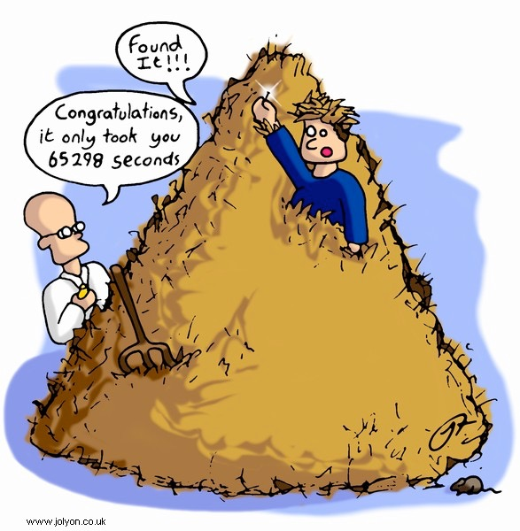

## The main question: $\mathcal{P}$ vs. $\mathcal{NP}$

**Does $\mathcal{P} = \mathcal{NP}$?** [Cook 1971, Edmonds, Levin, Yablonski, Gödel] Is the decision problem as easy as the certification problem?

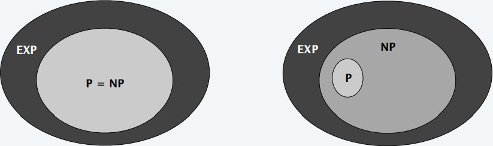

- **If yes**: Efficient algorithms for 3-SAT, TSP, VERTEX-COVER, FACTOR, etc.
- **If no**: No efficient algorithms possible for 3-SAT, TSP, VERTEX-COVER, etc.

**Consensus opinion**. Probably no.

## Possible outcomes: $\mathcal{P} \ne \mathcal{NP}$

> I conjecture that there is no good algorithm for the traveling salesman problem. My reasons are the same as for any mathematical conjecture: (i) It is a legitimate mathematical possibility and (ii) I do not know. — Jack Edmonds 1966

> In my view, there is no way to even make intelligent guesses about the answer to any of these questions. If I had to bet now, I would bet that $\mathcal{P}$ is not equal to $\mathcal{NP}$. I estimate the half-life of this problem at 25-50 more years, but I wouldn’t bet on it being solved before 2100. — Bob Tarjan (2002)

> We seem to be missing even the most basic understanding of the nature of its difficulty…. All approaches tried so far probably (in some cases, provably) have failed. In this sense $\mathcal{P} = \mathcal{NP}$ is different from many other major mathematical problems on which a gradual progress was being constantly done (sometimes for centuries) whereupon they yielded, either completely or partially. — Alexander Razborov (2002)

## Possible outcomes: $\mathcal{P} = \mathcal{NP}$

> I think that in this respect I am on the loony fringe of the mathematical community: I think (not too strongly!) that $\mathcal{P} = \mathcal{NP}$ and this will be proved within twenty years. Some years ago, Charles Read and I worked on it quite bit, and we even had a celebratory dinner in a good restaurant before we found an absolutely fatal mistake. — Béla Bollobás (2002)

> In my opinion this shouldn’t really be a hard problem; it’s just that we came late to this theory, and haven’t yet developed any techniques for proving computations to be hard. Eventually, it will just be a footnote in the books. ” — John Conway

## Other possible outcomes

$\mathcal{P} = \mathcal{NP}$, but only $Ω(n^{100})$ algorithm for 3-SAT.  
$\mathcal{P} \ne \mathcal{NP}$, but with $O(n \log^\ast n)$ algorithm for 3-SAT.  
$\mathcal{P} = \mathcal{NP}$ is independent (of ZFC axiomatic set theory).

> It will be solved by either 2048 or 4096. I am currently somewhat pessimistic. The outcome will be the truly worst case scenario: namely that someone will prove $\mathcal{P} = \mathcal{NP}$ because there are only finitely many obstructions to the opposite hypothesis; hence there exists a polynomial time solution to SAT but we will never know its complexity! — Donald Knuth

## Millennium prize

**Millennium prize**. $1 million for resolution of $\mathcal{P} \ne \mathcal{NP}$ problem.

- The Millennium Prize Problems are seven of the most well-known and important unsolved problems in mathematics.
  - https://brilliant.org/wiki/millennium-prize-problems/
- The prizes were announced at a meeting in Paris, held on May 24, 2000 at the Collège de France.
  - https://www.claymath.org/millennium-problems/millennium-prize-problems

## Princeton CS Building

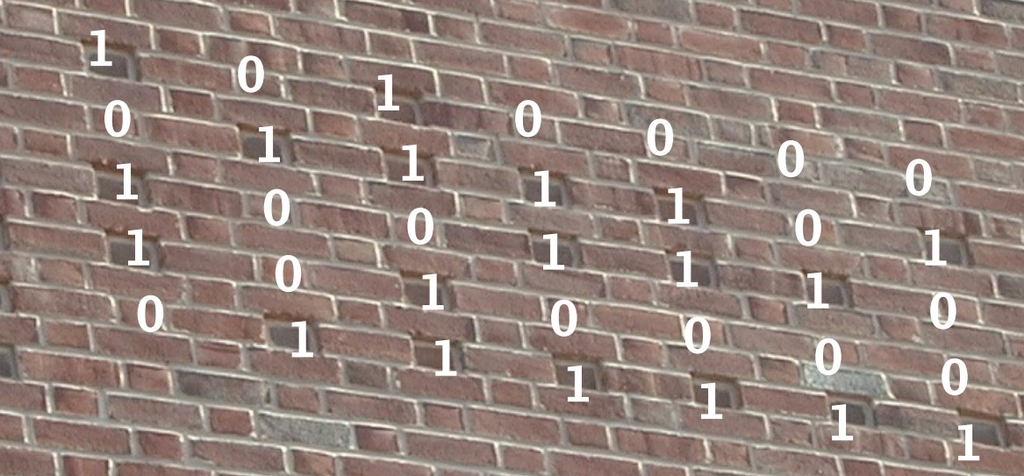

| binary | ASCII | char |
| --- | --- | --- |
| 1010000 | 80 | P |
| 0111101 | 61 | = |
| 1001110 | 78 | N |
| 1010000 | 80 | P |
| 0111111 | 63 | ? |

# $\mathcal{NP}$-complete

## Polynomial transformations

**Def**. Problem $X$ **polynomial (Cook) reduces** to problem $Y$ if arbitrary instances of problem $X$ can be solved using:

- Polynomial number of standard computational steps, plus
- Polynomial number of calls to oracle that solves problem $Y$.

**Def**. Problem $X$ **polynomial (Karp) transforms** to problem $Y$ if given any instance $x$ of $X$, we can construct an instance $y$ of $Y$ such that $x$ is a *yes* instance of $X$ iff $y$ is a *yes* instance of $Y$.

- we require $|y|$ to be of size polynomial in $|x|$

**Note**. Polynomial transformation is polynomial reduction with *just one call* to oracle for $Y$, exactly at the end of the algorithm for $X$. Almost all previous reductions were of this form.

**Open question**. Are these two concepts the same with respect to $\mathcal{NP}$?

## $\mathcal{NP}$-complete

**$\mathcal{NP}$-complete**. A problem $Y \in \mathcal{NP}$ with the property that for every problem $X \in \mathcal{NP}$, $X \le_P Y$.

- “hardest” $\mathcal{NP}$ problem.

**Proposition**. Suppose $Y \in$ $\mathcal{NP}$-complete. Then, $Y \in \mathcal{P}$ iff $\mathcal{P} = \mathcal{NP}$.  
**Pf**. $\Leftarrow$ If $\mathcal{P} = \mathcal{NP}$, then $Y \in \mathcal{P}$ because $Y \in \mathcal{NP}$.  
**Pf**. $\Rightarrow$ Suppose $Y \in \mathcal{P}$.

- Consider any problem $X \in \mathcal{NP}$. Since $X \le_P Y$, we have $X \in \mathcal{P}$.
- This implies $\mathcal{NP} \subseteq \mathcal{P}$.
- We already know $\mathcal{P} \subseteq \mathcal{NP}$. Thus $\mathcal{P} = \mathcal{NP}$.

**Fundamental question**. Are there any “natural” $\mathcal{NP}$-complete problems?

## The “first” $\mathcal{NP}$-complete problem

**Theorem**. [Cook 1971, Levin 1973] CIRCUIT-SAT $\in$ $\mathcal{NP}$-complete.

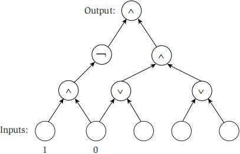

## Establishing NP-completeness

**Remark**. Once we establish first “natural” $\mathcal{NP}$-complete problem, others fall like dominoes.

**Recipe**. To prove that $Y \in$ $\mathcal{NP}$-complete:

1. Show that $Y \in \mathcal{NP}$.
2. Choose an $\mathcal{NP}$-complete problem $X$.
3. Prove that $X \le_P Y$.

**Proposition**. If $X \in$ $\mathcal{NP}$-complete, $Y \in \mathcal{NP}$, and $X \le_P Y$, then $Y \in$ $\mathcal{NP}$-complete.  
**Pf**. Consider any problem $W \in \mathcal{NP}$. Then, both $W \le_P X$ and $X \le_P Y$.

- By transitivity, $W \le_P Y$.
- Hence $Y \in$ $\mathcal{NP}$-complete.

## Quiz: $\mathcal{NP}$-complete

Suppose that $X \in$ $\mathcal{NP}$-complete, $Y \in \mathcal{NP}$, and $X \le_P Y$. Which can you infer?

**A**. $Y$ is $\mathcal{NP}$-complete.  
**B**. If $Y \notin \mathcal{P}$, then $\mathcal{P} \ne \mathcal{NP}$.  
**C**. If $\mathcal{P} \ne \mathcal{NP}$, then neither $X$ nor $Y$ is in $\mathcal{P}$.  
**D**. All of the above.

## Implications of Karp + Cook-Levin

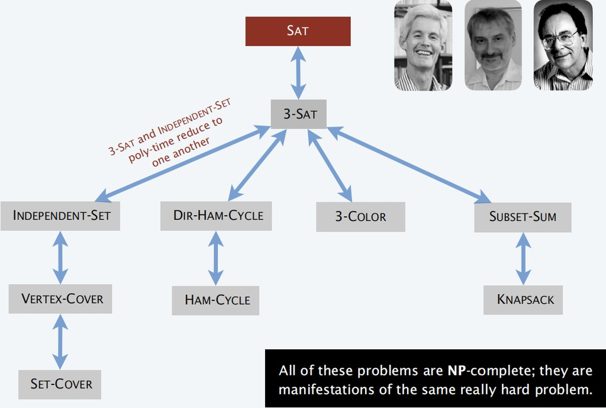

## Some $\mathcal{NP}$-complete problems

**Basic genres of $\mathcal{NP}$-complete problems and paradigmatic examples**.

- Packing/covering problems: SET-COVER, VERTEX-COVER,INDEPENDENT-SET.
- Constraint satisfaction problems: CIRCUIT-SAT, SAT, 3-SAT.
- Sequencing problems: HAM-CYCLE, TSP.
- Partitioning problems: 3D-MATCHING, 3-COLOR.
- Numerical problems: SUBSET-SUM, KNAPSACK.

**Practice**. Most $\mathcal{NP}$ problems are known to be either in $\mathcal{P}$ or $\mathcal{NP}$-complete.

**$\mathcal{NP}$-intermediate?** FACTOR, DISCRETE-LOG, GRAPH-ISOMORPHISM, etc.

**Theorem**. [Ladner 1975] Unless $\mathcal{P} = \mathcal{NP}$, there exist problems in $\mathcal{NP}$ that are neither in $\mathcal{P}$ nor $\mathcal{NP}$-complete.

## More hard computational problems

**Garey and Johnson**. Computers and Intractability.

- Appendix includes over 300 $\mathcal{NP}$-complete problems.
- Most cited reference in computer science literature.

# $\text{co-}NP$

## Asymmetry of $\mathcal{NP}$: ex 1

**Asymmetry of $\mathcal{NP}$**. We need short certificates only for $yes$ instances.

**Ex 1**. SAT vs. UN-SAT.

- Can prove a CNF formula is satisfiable by specifying an assignment.
- How could we prove that a formula is not satisfiable?

**SAT**. Given a CNF formula $Φ$, is there *a* satisfying truth assignment?

**UN-SAT**. Given a CNF formula $Φ$, is there *no* satisfying truth assignment?

## Asymmetry of $\mathcal{NP}$: ex 2

**Asymmetry of $\mathcal{NP}$**. We need short certificates only for $yes$ instances.

**Ex 2**. HAM-CYCLE vs. NO-HAM-CYCLE.

- Can prove a graph is Hamiltonian by specifying a permutation.
- How could we prove that a graph is not Hamiltonian?

**HAM-CYCLE**. Given a graph $G = (V, E)$, is there *a* simple cycle $Γ$ that contains every node in $V$?

**NO-HAM-CYCLE**. Given a graph $G = (V, E)$, is there *no* simple cycle $Γ$ that contains every node in $V$?

## Asymmetry of $\mathcal{NP}$: question

**Asymmetry of $\mathcal{NP}$**. We need short certificates only for $yes$ instances.

**Q**. How to classify UN-SAT and NO-HAM-CYCLE?

- SAT $\in$ $\mathcal{NP}$-complete and SAT $\equiv_P$ UN-SAT.
- HAM-CYCLE $\in$ $\mathcal{NP}$-complete and HAM-CYCLE $\equiv_P$ NO-HAM-CYCLE.
- But neither UN-SAT nor NO-HAM-CYCLE are known to be in $\mathcal{NP}$.

## $\mathcal{NP}$ and $\text{co-}NP$

**$\mathcal{NP}$**. Decision problems for which there is a poly-time certifier.  
**Ex**. SAT, HAM-CYCLE, and COMPOSITES.

**Def**. Given a decision problem $X$, its **complement** $\bar{X}$ is the same problem with $yes$ and $no$ answers reversed.

**Ex**. $X = \{ 4, 6, 8, 9, 10, 12, 14, 15, … \}$

- $\bar{X} = { 2, 3, 5, 7, 11, 13, 17, 23, 29, … }$
  - note: ignore 0 and 1 (neither prime nor composite)

**$\text{co-}NP$**. Complements of decision problems in $\mathcal{NP}$.  
**Ex**. UN-SAT, NO-HAM-CYCLE, and PRIMES.

## $\mathcal{NP} = \text{co-}NP$?

**Fundamental open question**. Does $\mathcal{NP} = \text{co-}NP$?

- Do $yes$ instances have succinct certificates iff $no$ instances do?
- Consensus opinion: no.

**Theorem**. If $\mathcal{NP} \ne \text{co-}NP$, then $\mathcal{P} \ne \mathcal{NP}$.  
**Pf idea**.

- $\mathcal{P}$ is closed under complementation.
- If $\mathcal{P} = \mathcal{NP}$, then $\mathcal{NP}$ is closed under complementation.
- In other words, $\mathcal{NP} = \text{co-}NP$.
- This is the contrapositive of the theorem.

## Good characterizations

**Good characterization**. [Edmonds 1965] $\mathcal{NP} \cap \text{co-}NP$.

- If problem $X$ is in both $\mathcal{NP}$ and $\text{co-}NP$, then:
  - for $yes$ instance, there is a succinct certificate
  - for $no$ instance, there is a succinct disqualifier
- Provides conceptual leverage for reasoning about a problem.

**Ex**. Given a bipartite graph, is there a perfect matching?

- If $yes$, can exhibit a perfect matching.
- If $no$, can exhibit a set of nodes $S$ such that $| neighbors(S) | < | S |$.
  - means: no need to enumerate all possibilities
  - note (as in paper): “… does *not* mean necessarily that there is a good algorithm.”

## Good characterizations: ex 1

**Observation**. $\mathcal{P} ⊆ \mathcal{NP} \cap \text{co-}NP$.

- Proof of max-flow min-cut theorem led to stronger result that max-flow and min-cut are in $\mathcal{P}$.
  - max-flow complements to min-cut
- Sometimes finding a good characterization seems easier than finding an efficient algorithm.

**Fundamental open question**. Does $\mathcal{P} = \mathcal{NP} \cap \text{co-}NP$?

- Mixed opinions.
- Many examples where problem found to have a nontrivial good characterization, but only years later discovered to be in $\mathcal{P}$.

## Linear programming is in $\mathcal{NP} \cap \text{co-}NP$

**LINEAR-PROGRAMMING**. Given $A \in \Re^{m \times n}, b \in \Re^m, c \in \Re^n$, and $\alpha \in \Re$, does there exist $x \in \Re^n$ such that $Ax \le b, x \ge 0$ and $cT x \ge \alpha$?

**Theorem**. [Gale-Kuhn-Tucker 1948] LINEAR-PROGRAMMING $\in \mathcal{NP} \cap \text{co-}NP$.  
**Pf sketch**. If (P) and (D) are nonempty, then `max` = `min`.

$$\begin{aligned}
\text{(Primary)} \max c^Tx && \\
\text{s.t.} && Ax & \le b \\
&& x & \ge 0 \\
\end{aligned}$$

$$\begin{aligned}
\text{(Dual)} \min y^Tb && \\
\text{s.t.} && A^Ty & \ge c \\
&& y & \ge 0 \\
\end{aligned}$$

**Theorem**. [Khachiyan 1979] LINEAR-PROGRAMMING $\in \mathcal{P}$.

## Primality testing is in $\mathcal{NP} \cap \text{co-}NP$

**Theorem**. [Pratt 1975] PRIMES $\in \mathcal{NP} \cap \text{co-}NP$.  
**Pf sketch**. An odd integer $s$ is prime iff there exists an integer $1 < t < s$ s.t.

$$\begin{aligned}
t^{s-1} & \equiv 1 \pmod{s} \\
t^{\frac{s-1}{p}} & \ne 1 \pmod{s} \\
\end{aligned}$$

for all prime divisors $p$ of $s-1$.

- instance $s$: $437677$
- certificate $t$: $17, 2^2 \times 3 \times 36473$
  - prime factorization of $s-1$ also need a recursive certificate to assert 36,473 is prime

`CERTIFIER` ($s$)

CHECK $s - 1 = 2 \times 2 \times 3 \times 36473$.  
CHECK $17^{s-1} = 1 \pmod{s}$.  
CHECK $17^{(s-1) / 2} \equiv 437676 \pmod{s}$.  
CHECK $17^{(s-1) / 3} \equiv 329415 \pmod{s}$.  
CHECK $17^{(s-1) / 36,473} \equiv 305452 \pmod{s}$.

## Primality testing is in $\mathcal{P}$

**Theorem**. [Agrawal-Kayal-Saxena 2004] PRIMES $\in \mathcal{P}$.

## Factoring is in $\mathcal{NP} \cap \text{co-}NP$

**FACTORIZE**. Given an integer $x$, *find* its prime factorization.  
**FACTOR**. Given two integers $x$ and $y$, does x have a nontrivial factor $< y$?

**Theorem**. FACTOR $\equiv_P$ FACTORIZE.  
**Pf**.

- $\le \mathcal{P}$ trivial.
- $\ge \mathcal{P}$ binary search to find a factor; divide out the factor and repeat.

## Is factoring in $\mathcal{P}$?

**Fundamental question**. Is FACTOR $\in \mathcal{P}$?

**Challenge**. [RSA-704] Factor this number.

$$74037563479561712828046796097429573142593188889231289\\
08493623263897276503402826627689199641962511784399589\\
43305021275853701189680982867331732731089309005525051\\
16877063299072396380786710086096962537934650563796359\\$$

($30,000 prize if you can factor)

## Exploiting intractability

**Modern cryptography**.

- **Ex**. Send your credit card number to Amazon.
- **Ex**. Digitally sign an e-document.
- Enables freedom of privacy, speech, press, etc.

**RSA**. Based on dichotomy between complexity of two problems.

- To use: generate two random $n$-bit primes and multiply.
- To break: suffices to factor a $2n$-bit integer.

## Factoring on a quantum computer

**Theorem**. [Shor 1994] Can factor an $n$-bit integer in $O(n^3)$ steps on a “quantum computer.”

**2001**. Factored $15 = 3 \times 5$ (with high probability) on a quantum computer.  
**2012**. Factored $21 = 3 \times 7$.

**Fundamental question**. Does $\mathcal{P} = \mathcal{BQP}$?

- quantum analog of $\mathcal{P}$ (bounded error quantum polynomial time)

# $\mathcal{NP}$-hard

## A note on terminology

**A Terminological Proposal**. [Knuth 1974]

> I needed an adjective to convey such a degree of difficulty, both formally and informally; … The goal is to find an adjective `x` that sounds good in sentences like this:
> - The covering problem is `x`.
> - It is `x` to decide whether a given graph has a Hamiltonian circuit.
> - It is unknown whether or not primality testing ia an `x` problem.

**Note**. The term `x` does not necessarily imply that a problem is in $\mathcal{NP}$, just that every problem in $\mathcal{NP}$ poly-time reduces to `x`.

## Terminology suggestions

**Knuth’s original suggestions**.

- Hard, Tough: too common and may already been used.
- Herculean, Formidable, Arduous: arcane.

**Some English word write-ins**.

- Impractical.
- Bad.
- Heavy.
- Tricky.
- Intricate.
- Prodigious.
- Difficult.
- Intractable.
- Costly.
- Obdurate.
- Obstinate.
- Exorbitant.
- Interminable.

## Terminology in literature

**Hard-boiled**. [Ken Steiglitz] In honor of Cook.

**Hard-ass**. [Al Meyer] Hard AS Satisfiability.

**Sisyphean**. [Bob Floyd] Problem of Sisyphus was time-consuming.

**Ulyssean**. [Donald Knuth] Ulysses was known for his persistence.

> “ creative research workers are as full of ideas for new terminology as they are empty of enthusiasm for adopting it. ” — Donald Knuth

## Terminology: acronyms

**PET**. [Shen Lin] Probably Exponential Time.

- If $\mathcal{P} \ne \mathcal{NP}$, Provably Exponential Time.
- If $\mathcal{P} = \mathcal{NP}$, Previously Exponential Time.

**GNP**. [Al Meyer] Greater than or equal to $\mathcal{NP}$ in difficulty.

- And costing more than the GNP to solve.

## Terminology: made-up words

**Exparent**. [Mike Paterson] Exponential + apparent.

**Perarduous**. [Mike Paterson] Throughout (in space or time) + completely.

**Supersat**. [Al Meyer] Greater than or equal to satisfiability.

**Polychronious**. [Ed Reingold] Enduringly long; chronic.

## Terminology: consensus

**$\mathcal{NP}$-complete**. A problem in $\mathcal{NP}$ such that every problem in $\mathcal{NP}$ poly-time reduces to it.

**$\mathcal{NP}$-hard**. [Bell Labs, Steve Cook, Ron Rivest, Sartaj Sahni]  
A problem such that every problem in $\mathcal{NP}$ poly-time reduces to it.

> “If the Martians know that $\mathcal{P} = \mathcal{NP}$ for Turing Machines and they kidnap me, I would lose face calling these problems ‘formidable’.” — Vaughan Pratt.